# **Practical Machine Learning Project**

#### 25 December 2015

### **Introduction**

Using devices such as Jawbone Up, Nike FuelBand, and Fitbit is now possible to collect a large amount of data about personal activity relatively inexpensively. These type of devices are part of the quantified self movement - a group of enthusiasts who take measurements about themselves regularly to improve their health, to find patterns in their behavior, or because they are tech geeks. One thing that people regularly do is quantify how much of a particular activity they do, but they rarely quantify how well they do it.

In this project, the goal is to use data from accelerometers on the belt, forearm, arm, and dumbell of 6 participants to predict the manner they did the exercise. They were asked to perform barbell lifts correctly and incorrectly in 5 different ways. Namely

- Class A : exactly according to the specification
- Class B : throwing the elbows to the front
- Class C : lifting the dumbbell only halfway
- Class D : lowering the dumbbell only halfway
- Class E : throwing the hips to the front

In other words, dependent variables are Class A to Class E. More information is available from the website here: http://groupware.les.inf.puc-rio.br/har (see the section on the Weight Lifting Exercise Dataset).

### **Data Processing**

```r
# load packages
library(caret)
library(randomForest)
library(corrplot)
```

```r
# download the CSV file from the web location and read in to R dataset
rm(list = ls())
if (!file.exists("pml-training.csv")) {
        download.file("http://d396qusza40orc.cloudfront.net/predmachlearn/pml-training.csv", destfile = "pml-training.csv")
}
if (!file.exists("pml-testing.csv")) {
        download.file("http://d396qusza40orc.cloudfront.net/predmachlearn/pml-testing.csv", destfile = "pml-testing.csv")
}
trainRaw <- read.csv("pml-training.csv", na.strings = c("NA", ""))
testRaw  <- read.csv("pml-testing.csv", na.strings = c("NA", ""))
```

```r
str(trainRaw)                   # 19622 obs. of  160 variables
sum(complete.cases(trainRaw))   # 406 complete cases
```

Remove columns that all values are missing

```r
trainRaw <- trainRaw[, colSums(is.na(trainRaw)) == 0]
testRaw <- testRaw[, colSums(is.na(testRaw)) == 0]
```

Remove first 7 columns since they are obviously not relevant in predicting Class. They are timestamps, names and windows variables. There are 53 variables remaining in both trainData and testData. 19622 obs in trainData and 20 obs in testData. The dependent variable is classe.

```r
trainingData <- trainRaw[, -c(1:7)]
testData <- testRaw[, -c(1:7)]
```

### **Slicing the Data**

For the purpose of cross validation, split the train data set into a 70% of pure train and 30% of validation data set.

```r
set.seed(666) # For reproducibile purpose
inTrain <- createDataPartition(trainingData$classe, p=0.7, list=FALSE)
trainData <- trainingData[inTrain, ]
validateData  <- trainingData[-inTrain, ]
```

### **Prediction Model**

Random forest is accurate can handle large number of predictors without variable deletion. It also provide list of variable importance to indicate the relative predictive power of the independent variables. It is robust to correlated covariates and outliers.

As cross validation provides a more accurate result by averageing several models, we use 5 folds validation to apply the random forest algorithm.

```r
rf.fit <-train(classe ~ ., data=trainData, method="rf", trControl= trainControl(method="cv", 5), ntree=250)
print(rf.fit)
```

```
## Random Forest
##
## 13737 samples
##    52 predictor
##     5 classes: 'A', 'B', 'C', 'D', 'E'
##
## No pre-processing
## Resampling: Cross-Validated (5 fold)
## Summary of sample sizes: 10990, 10989, 10990, 10989, 10990
## Resampling results across tuning parameters:
##
##   mtry  Accuracy   Kappa      Accuracy SD  Kappa SD
##    2    0.9900270  0.9873837  0.001399888  0.001770843
##   27    0.9916284  0.9894097  0.001338086  0.001693650
##   52    0.9827469  0.9781745  0.003373840  0.004269169
##
## Accuracy was used to select the optimal model using  the largest value.
## The final value used for the model was mtry = 27.
```

### **Results from Fitting Random Forest**

Top 20 predictors by variable importance are as below

```r
varImp(rf.fit,scale = FALSE)
```

```
## rf variable importance
##
##   only 20 most important variables shown (out of 52)
##
##                      Overall
## roll_belt             1386.6
## pitch_forearm          874.2
## yaw_belt               762.6
## pitch_belt             633.2
## magnet_dumbbell_y      631.0
## magnet_dumbbell_z      623.9
## roll_forearm           598.9
## accel_dumbbell_y       316.1
## magnet_dumbbell_x      273.1
## accel_forearm_x        267.2
## roll_dumbbell          267.0
## magnet_belt_z          223.9
## accel_belt_z           217.4
## total_accel_dumbbell   216.7
## magnet_forearm_z       214.0
## accel_dumbbell_z       213.5
## magnet_belt_y          201.4
## gyros_belt_z           167.1
## magnet_belt_x          162.2
## yaw_arm                160.1
```

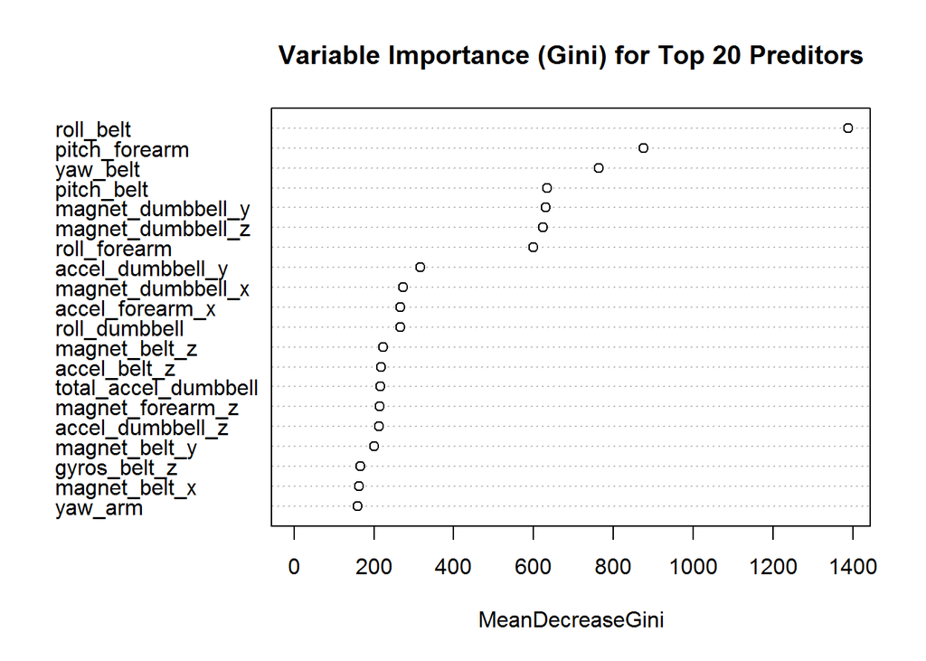

```r
varImpPlot(rf.fit$finalModel, scale = FALSE, n.var=20, main = "Variable Importance (Gini) for Top 20 Preditors")
```

### **Confusion Matrix on Validate Data**

```r
predict.rf <- predict(rf.fit, validateData)
conf.matrix <- confusionMatrix(validateData$classe, predict.rf)
print(conf.matrix)
```

```
## Confusion Matrix and Statistics
##
##           Reference
## Prediction    A    B    C    D    E
##          A 1672    2    0    0    0
##          B    9 1124    6    0    0
##          C    0    2 1022    2    0
##          D    0    0   10  951    3
##          E    0    1    2    7 1072
##
## Overall Statistics
##
##                Accuracy : 0.9925
##                  95% CI : (0.99, 0.9946)
##     No Information Rate : 0.2856
##     P-Value [Acc > NIR] : < 2.2e-16
##
##                   Kappa : 0.9905
##  Mcnemar's Test P-Value : NA
##
## Statistics by Class:
##
##                      Class: A Class: B Class: C Class: D Class: E
## Sensitivity            0.9946   0.9956   0.9827   0.9906   0.9972
## Specificity            0.9995   0.9968   0.9992   0.9974   0.9979
## Pos Pred Value         0.9988   0.9868   0.9961   0.9865   0.9908
## Neg Pred Value         0.9979   0.9989   0.9963   0.9982   0.9994
## Prevalence             0.2856   0.1918   0.1767   0.1631   0.1827
## Detection Rate         0.2841   0.1910   0.1737   0.1616   0.1822
## Detection Prevalence   0.2845   0.1935   0.1743   0.1638   0.1839
## Balanced Accuracy      0.9971   0.9962   0.9909   0.9940   0.9976
```

```r
accuracy <- conf.matrix$overall[1]
Out.of.sample.Error <- 1 - accuracy
print(accuracy)
```

```
##  Accuracy
## 0.9925234
```

```r
print(Out.of.sample.Error)
```

```
##    Accuracy
## 0.007476636
```

Using random forest, estimated accuracy rate is 99.3% and estimated out-of-sample error rate is 0.7%.

### **Prediction on Test Data**

Now, use the random forest model to predict the dependent variable classe for the test dataset.

```r
predict(rf.fit, testData)
```

```
##  [1] B A B A A E D B A A B C B A E E A B B B
## Levels: A B C D E
```